# Text-Mining and Keyword Analysis

Christopher Jones

What follows is a text-mining analysis of recent customer reviews. This analysis, descriptive in nature, is followed by a summary of preliminary results from recent predictive analyses examining the relationship between word frequency and the likelihood of repeat purchase. In simpler terms: customer reviews were mined for keywords, and keywords were correlated with likelihood of repeat purchase to discover statistical significance.

All analyses are conducted in R.

### Load Necessary Libraries, Read-In Relevant Data, and Manipulate Data

Below is code used to create a data frame of each customer’s review. It also provides an example of the procedures used to conduct each text-mining analysis.

```r
library(tm)
library(SnowballC)
library(wordcloud)
library(RColorBrewer)
library(wordcloud2)
library(ggplot2)

cname <- file.path("~", "Desktop", "text_mine", "text")

docs <- VCorpus(DirSource(cname))

docs <- tm_map(docs,removePunctuation)
for (j in seq(docs)) {
  docs[[j]] <- gsub("/", " ", docs[[j]])
  docs[[j]] <- gsub("@", " ", docs[[j]])
  docs[[j]] <- gsub("\\|", " ", docs[[j]])
  docs[[j]] <- gsub("\u2028", " ", docs[[j]])
}

docs <- tm_map(docs, removeNumbers)
docs <- tm_map(docs, tolower)
docs <- tm_map(docs, PlainTextDocument)

docs <- tm_map(docs, removeWords, stopwords("english"))
docs <- tm_map(docs, PlainTextDocument)

docs <- tm_map(docs, removeWords, c("the", "and", "itds", "can"))

for (j in seq(docs))
{
  docs[[j]] <- gsub("crew neck", "crewneck", docs[[j]])
}
docs <- tm_map(docs, PlainTextDocument)

docs <- tm_map(docs, stripWhitespace)
docs <- tm_map(docs, PlainTextDocument)

dtm <- DocumentTermMatrix(docs)

tdm <- TermDocumentMatrix(docs)
m <- as.matrix(dtm)

dtms <- removeSparseTerms(dtm, 0.2)
freq <- colSums(as.matrix(dtm))
freq <- colSums(as.matrix(dtms))
freq <- sort(colSums(as.matrix(dtm)), decreasing=TRUE)

wf <- data.frame(word=names(freq), freq=freq)
```

### Word Cloud to Assess Frequency of Keywords

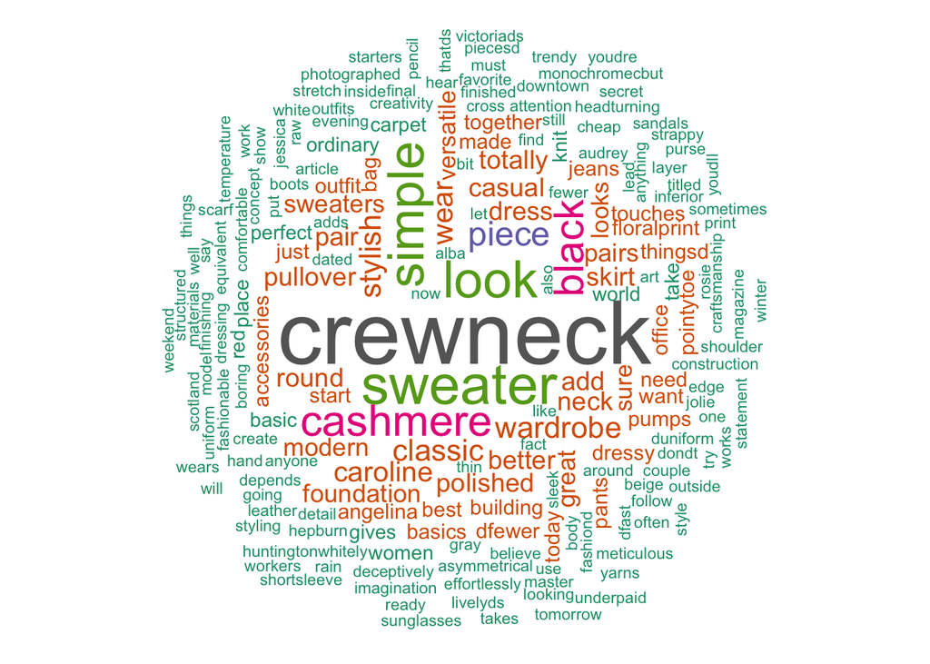

```r
set.seed(1234)
wordcloud(words = wf$word, freq = wf$freq, min.freq = 1,
          max.words=200, random.order=FALSE, rot.per=0.35, shape = 'circle',
          colors=brewer.pal(8, "Dark2"))
```

### Bar Chart and Radial Chart to Assess Frequency of Keywords

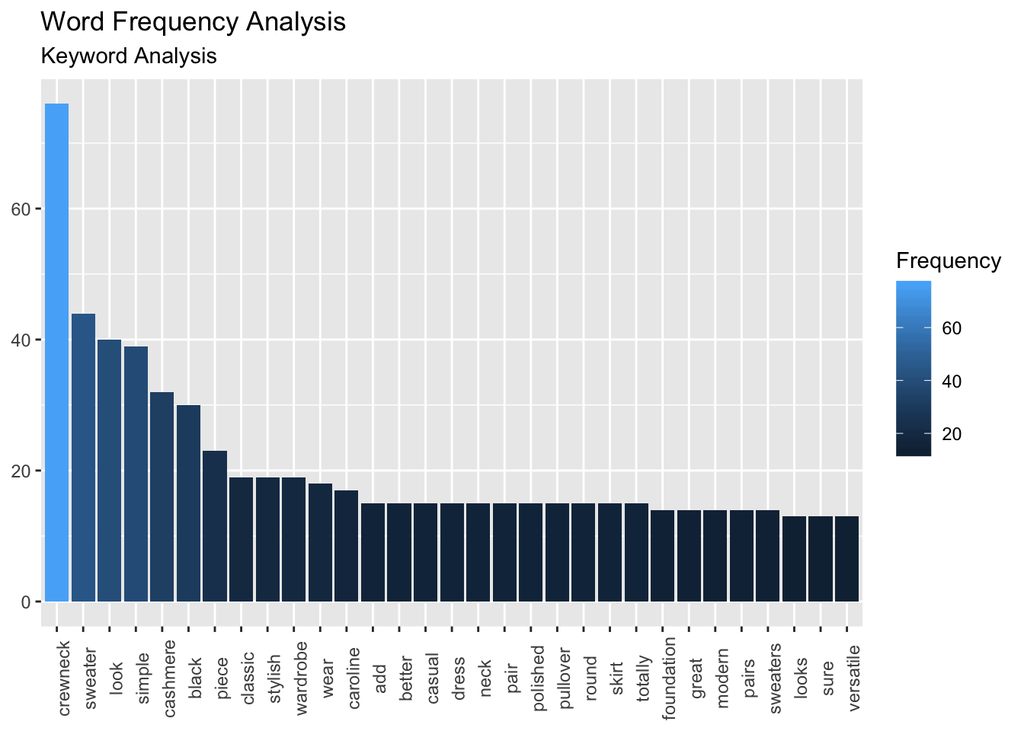

```r
p <- ggplot(subset(wf, freq>10), aes(x = reorder(word, -freq), y = freq, fill = freq)) +
  geom_bar(stat = "identity") +
  labs(title="Word Frequency Analysis",
       subtitle= "Keyword Analysis") +
  labs(x = NULL, y = NULL, fill= "Frequency") +
  theme(plot.subtitle = element_text(vjust = 1),
        plot.caption = element_text(vjust = 1),
        axis.text.x = element_text(angle = 90))
p
```

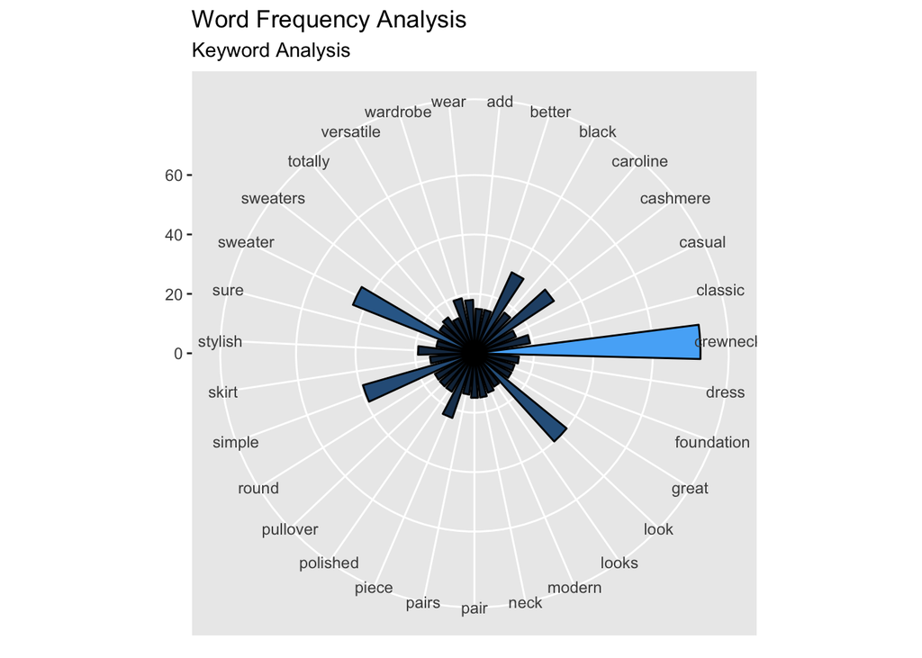

```r
ggplot(subset(wf, freq>12), aes(x=word, y=freq, fill=freq)) +
  geom_bar(width = 0.75,  stat = "identity", colour = "black", size = .5) +
  coord_polar(theta = "x") +
  xlab("") + ylab("") +
  labs(title="Word Frequency Analysis",
       subtitle= "Keyword Analysis") +
  theme(legend.position = "none") +
  labs(x = NULL, y = NULL)
```